# Datos sobre Pokémon

Flores-Guevara

31 / julio / 2021

[figure not shown]

En esta web encontrarás un breve análisis sobre datos de Pokémon, esas criaturas con las cuales hemos pasado parte de nuestra infancia/ adolescencia (y parte de nuestra vida adulta también 😺). Previo a sumergirnos en los datos, haremos una breve introducción al mundo Pokémon contándote un poco sobre estas facinantes criaturas.

## ¿Qué es Pokémon?

Es una franquicia que inició originalmente como un videojuego de RPG (Role Playing Game) y que luego se expandió a diversos medios como serie televisiva, juego de cartas, ropa, entre otros. La palabra **Pokémon** deriva de una contracción de **poket monsters** (monstruos de bolsillo). Los Pokémon son criaturas inspiradas en animales, objetos, plantas o criaturas mitológicas. Los jugadores de este videojuego son conocidos como entrenadores Pokémon y sus objetivos son recopilar todas las especies de Pokémon, “atraparlos” y entrenarlos para poder competir con otros entrenadores y determinar quién posee los Pokémon más fuertes.

## ¡Un poco de nostalgia!

Por si no tenés idea de lo que es Pokémon te dejamos el *openning* (presentacion inicial) de la primer entrega de la serie televisiva, emitida en el año 1997. Esta temporada se desarrolla en la región Kanto, hogar de alrededor de 150 tipos de Pokémon, y del protagonista Ash Ketchum, quien junto a su compañero Pikachu, sale a retar Gimnasios Pokémon y a ganar un lugar en el Torneo de la Liga Índigo.

[video not shown]

## Dataset de Pokémon

### Tipos de Pokémon

A continuación en el gráfico 1 se muestran los distintos tipos existentes en la primer generación Pokémon. Cabe destacar que un Pokémon puede tener hasta dos tipos. En este primer análisis nos centraremos solo en el primer tipo, sin importar si los Pokémon tienen más de un tipo:

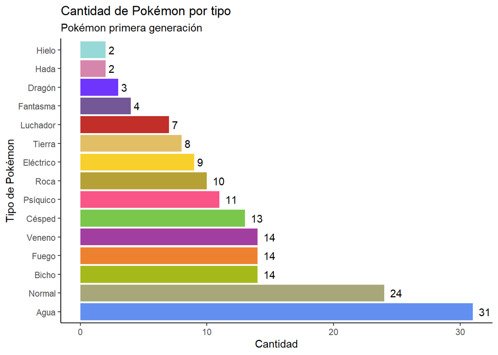

Figure 1: Cantidad de Pokémon por tipo

Como se puede observar existe una mayor cantidad de Pokémons del tipo agua, por lo que será mas probable que nos encontremos con un Pokémon de este tipo que por ejemplo con uno de tipo Hielo o Hada.

### Cuál es el tipo de Pokémon con mejores estadísticas?

Table 1: Tipo de Pokémon con mejores estadísticas

| tipo_1 | Total | Ataque | Defensa | Salud | Velocidad | Ataque_especial | Defensa_especial |
| --- | --- | --- | --- | --- | --- | --- | --- |
| Dragón | 550.5 | 112.1 | 86.4 | 83.3 | 83.0 | 96.8 | 88.8 |
| Acero | 487.7 | 92.7 | 126.4 | 65.2 | 55.3 | 67.5 | 80.6 |
| Volador | 485.0 | 78.8 | 66.2 | 70.8 | 102.5 | 94.2 | 72.5 |
| Psíquico | 475.9 | 71.5 | 67.7 | 70.6 | 81.5 | 98.4 | 86.3 |
| Fuego | 458.1 | 84.8 | 67.8 | 69.9 | 74.4 | 89.0 | 72.2 |

La tabla 1 nos proporciona un primer acercamiento a este **top 5** de Pokémon **más fuertes**. Para una rápida observación hemos ordenado los datos en forma descendente, de modo tal que los tipos que mejor estadísticas tengan aparezan primeros. Con los datos obtenidos realizaremos una visualizacion gráfica en *boxplots* (gráfico 2) para comparar los puntos totales entre los diferentes tipos de Pokémon observados en la tabla anterior:

[figure not shown]

Figure 2: Top 5 de Pokémon con mayores stats totales promedio

Del análisis del gráfico 2 de cajas podemos observar que que los Pókemon tipo *dragon* son los “más fuertes”. Sin embargo, un hecho destacable es que los Pokémon del tipo psíquico tienen ejemplares casi tan fuertes como los dragones, pero a la vez también contienen a los mas débiles de este ranking. Al mirar la gráfica correspondiente al tipo volador, observamos que no hay *bigotes* como en las otras cajas y existe un valor *outlier*.

Una consideración importante que debemos realizar a esta altura, es que si bien los Pokémon del tipo dragón son los que mejores puntos promedio tienen, en el gráfico 1 solo se observan 3 Pokémon de dicho tipo. Esto nos permite suponer que los dragones no son un tipo de Pokémon que encontraremos habitualmente, y que si bien *son los más fuertes*, quizás nos convenga capturar alguno de tipo fuego o psíquico en vez de esperar cruzarnos al ansiado dragón.

Ahora si, volvamos a nuestros valores más altos. Dentro del tipo dragón, el Pokémon que tiene puntos característicos más altos es **Dragonite**, que pertenece a la primer generación de Pokémon y está identificado con el número 149. Dragonite se destaca por ser un Pokémon bondadoso y compasivo al que le resulta imposible dar la espalda a otros Pokémon o humanos que se encuentren a la deriva. A continuacióm en el gráfico 3 podremos observar un Dragonite y sus stats:

[figure not shown]

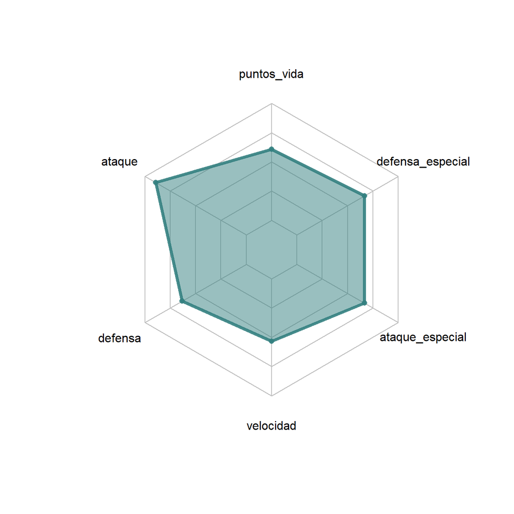

Figure 3: Dragonite

### Distribución de los stats de los tipos de Pokémon más fuertes

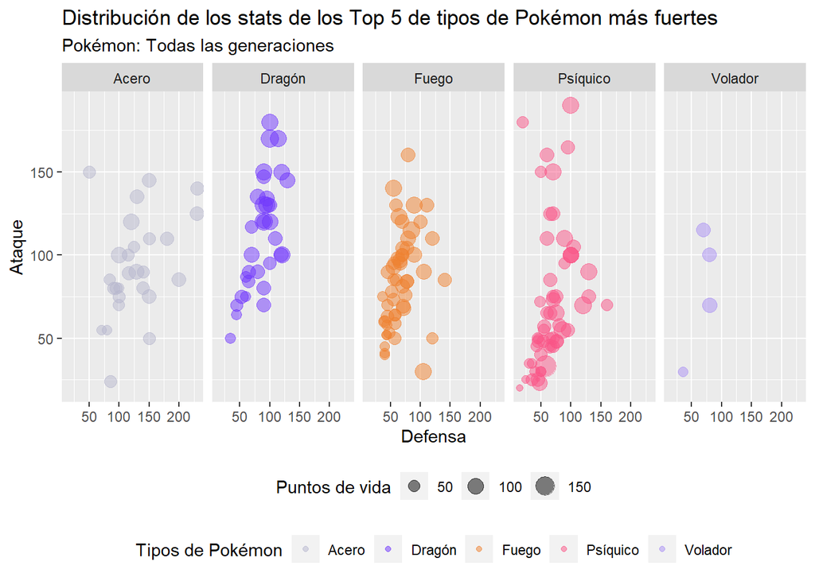

Figure 4: Distribución de los stats de los Top 5 de tipos de Pokémon más fuertes

Esten atentos y atentas, y prepárense para más información, visualizaciones y estadísticas sobre sus Pokémon favoritos.

**Patricia, G. - Nicolás, F.**